# Homework 3

PSTAT 131/231

## Classification

For this assignment, we will be working with part of a [Kaggle data set](https://www.kaggle.com/c/titanic/overview) that was the subject of a machine learning competition and is often used for practicing ML models. The goal is classification; specifically, to predict which passengers would survive the [Titanic shipwreck](https://en.wikipedia.org/wiki/Titanic).

Load the data from `data/titanic.csv` into *R* and familiarize yourself with the variables it contains using the codebook (`data/titanic_codebook.txt`).

```r
titanic <- read_csv('data/titanic.csv')
head(titanic)
```

```
## # A tibble: 6 × 12
##   passenger_id survived pclass name  sex     age sib_sp parch ticket  fare cabin
##          <dbl> <chr>     <dbl> <chr> <chr> <dbl>  <dbl> <dbl> <chr>  <dbl> <chr>
## 1            1 No            3 Brau… male     22      1     0 A/5 2…  7.25 <NA>
## 2            2 Yes           1 Cumi… fema…    38      1     0 PC 17… 71.3  C85
## 3            3 Yes           3 Heik… fema…    26      0     0 STON/…  7.92 <NA>
## 4            4 Yes           1 Futr… fema…    35      1     0 113803 53.1  C123
## 5            5 No            3 Alle… male     35      0     0 373450  8.05 <NA>
## 6            6 No            3 Mora… male     NA      0     0 330877  8.46 <NA>
## # … with 1 more variable: embarked <chr>
```

Notice that `survived` and `pclass` should be changed to factors. When changing `survived` to a factor, you may want to reorder the factor so that *“Yes”* is the first level.

```r
titanic$survived <- as.factor(titanic$survived) %>% relevel('Yes')
titanic$pclass <- as.factor(titanic$pclass)
```

Make sure you load the `tidyverse` and `tidymodels`!

*Remember that you’ll need to set a seed at the beginning of the document to reproduce your results.*

### Question 1

Split the data, stratifying on the outcome variable, `survived.` You should choose the proportions to split the data into. Verify that the training and testing data sets have the appropriate number of observations. Take a look at the training data and note any potential issues, such as missing data.

```r
set.seed(040404)

titanic_split <- initial_split(titanic, prop=0.75, strata=survived)
titanic_train <- training(titanic_split)
titanic_test <- testing(titanic_split)
```

Why is it a good idea to use stratified sampling for this data?

Stratified sampling is likely to be a good idea because of the nature of this data, where there already exists subdivisions based on class, gender, and age.

### Question 2

Using the **training** data set, explore/describe the distribution of the outcome variable `survived`.

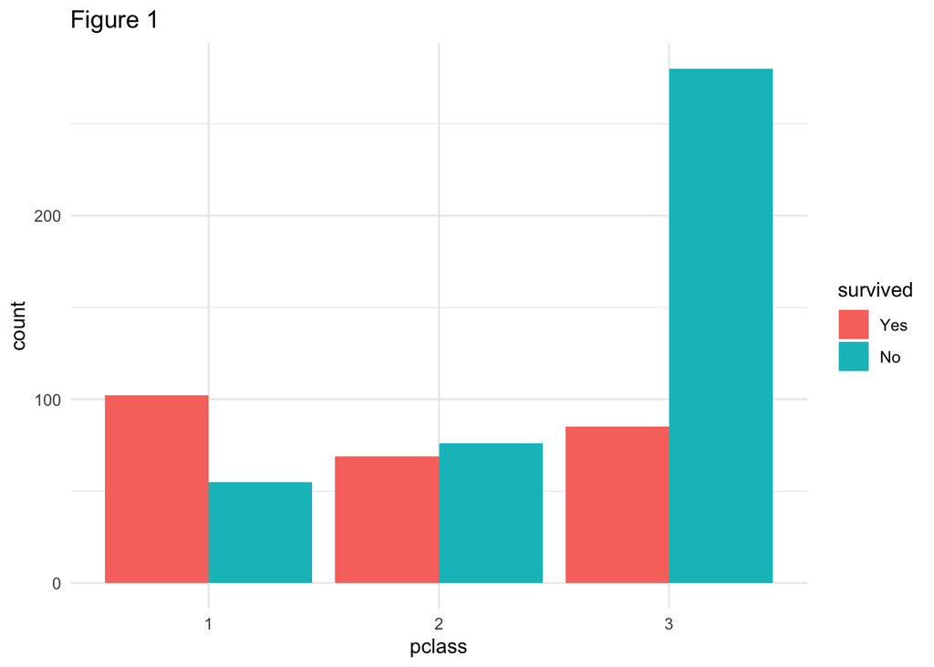

```r
titanic_train %>%
  ggplot(aes(x=pclass, fill=survived)) +
  geom_bar(stat="count", position = "dodge") +
  theme_minimal() +
  labs(title='Figure 1')
```

As seen in *Figure 1*, there is a correlation between `pclass` and the likelihood of survival is there. Lower classes have higher proportions of the population which did not survive.

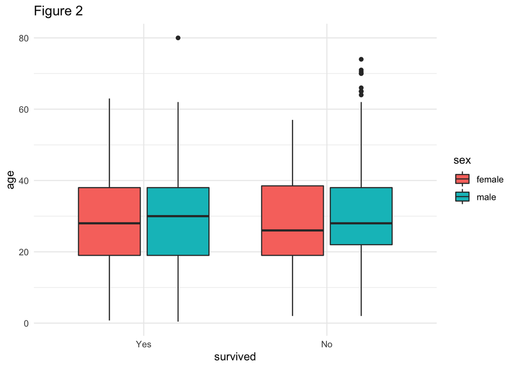

```r
titanic_train %>%
  ggplot(aes(x=survived, y=age, fill=sex)) +
  geom_boxplot() +
  theme_minimal() +
  labs(title='Figure 2')
```

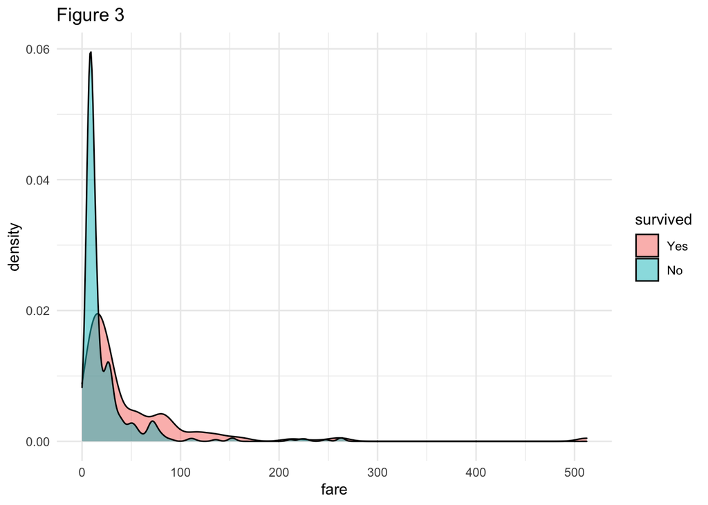

```r
titanic_train %>%
  ggplot(aes(x=fare, fill=survived)) +
  geom_density(alpha=0.5) +
  theme_minimal() +
  labs(title='Figure 3')
```

*Figure 3* displays the density of fare among those who survived and did not survive. There is a clear correlation between the cost of a ticket onto the titanic, and survival. For the most part the tickets which costed the least had the highest rate of death. There are some higher price tickets which see a higher rate of death as well, but it seems to be fairly even, especially for tickets in the range of 200-300.

### Question 3

Using the **training** data set, create a correlation matrix of all continuous variables. Create a visualization of the matrix, and describe any patterns you see. Are any predictors correlated with each other? Which ones, and in which direction?

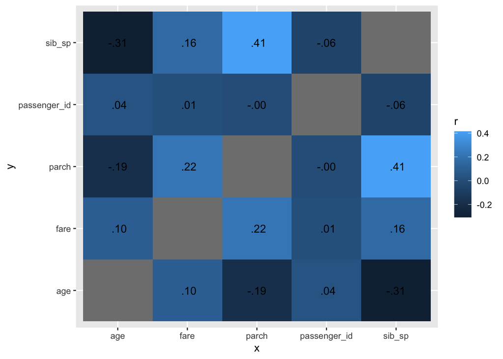

```r
cor_titanic <- titanic %>%
  select(-c(survived, sex)) %>%
  correlate()

cor_titanic %>%
  stretch() %>%
  ggplot(aes(x, y, fill=r)) +
  geom_tile() +
  geom_text(aes(label = as.character(fashion(r))))
```

The correlation matrix points to a lack of much correlation between these variables, but there is a slight positive correlation between `sib_sp` and `parch` as well as a slight negative correlation between `age` and `sib_sp`.

### Question 4

Using the **training** data, create a recipe predicting the outcome variable `survived`. Include the following predictors: ticket class, sex, age, number of siblings or spouses aboard, number of parents or children aboard, and passenger fare.

Recall that there were missing values for `age`. To deal with this, add an imputation step using `step_impute_linear()`. Next, use `step_dummy()` to **dummy** encode categorical predictors. Finally, include interactions between:

- Sex and passenger fare, and
- Age and passenger fare.

You’ll need to investigate the `tidymodels` documentation to find the appropriate step functions to use.

```r
titanic_recipe <- recipe(titanic_train,
                         survived ~ pclass + sex + age + sib_sp + parch + fare) %>%
  step_impute_linear(age, impute_with=imp_vars(sib_sp)) %>%
  step_dummy(all_nominal_predictors()) %>%
  step_interact(~ starts_with('sex'):fare + age:fare)
```

### Question 5

Specify a **logistic regression** model for classification using the `"glm"` engine. Then create a workflow. Add your model and the appropriate recipe. Finally, use `fit()` to apply your workflow to the **training** data.

*Hint: Make sure to store the results of `fit()`. You’ll need them later on.*

```r
log_reg <- logistic_reg() %>%
  set_engine('glm') %>%
  set_mode('classification')

log_wkflow <- workflow() %>%
  add_model(log_reg) %>%
  add_recipe(titanic_recipe)

log_fit <- fit(log_wkflow, titanic_train)
```

### Question 6

**Repeat Question 5**, but this time specify a linear discriminant analysis model for classification using the `"MASS"` engine.

```r
lda_mod <- discrim_linear() %>%
  set_engine('MASS') %>%
  set_mode('classification')

lda_wkflow <- workflow() %>%
  add_model(lda_mod) %>%
  add_recipe(titanic_recipe)

lda_fit <- fit(lda_wkflow, titanic_train)
```

### Question 7

**Repeat Question 5**, but this time specify a quadratic discriminant analysis model for classification using the `"MASS"` engine.

```r
qda_mod <- discrim_quad() %>%
  set_engine('MASS') %>%
  set_mode('classification')

qda_wkflow <- workflow() %>%
  add_model(qda_mod) %>%
  add_recipe(titanic_recipe)

qda_fit <- fit(qda_wkflow, titanic_train)
```

### Question 8

**Repeat Question 5**, but this time specify a naive Bayes model for classification using the `"klaR"` engine. Set the `usekernel` argument to `FALSE`.

```r
nb_mod <- naive_Bayes() %>%
  set_mode('classification') %>%
  set_engine('klaR') %>%
  set_args(usekernel = FALSE)

nb_wkflow <- workflow() %>%
  add_model(nb_mod) %>%
  add_recipe(titanic_recipe)

nb_fit <- fit(nb_wkflow, titanic_train)
```

### Question 9

Now you’ve fit four different models to your training data.

Use `predict()` and `bind_cols()` to generate predictions using each of these 4 models and your **training** data. Then use the *accuracy* metric to assess the performance of each of the four models.

```r
log_acc <- predict(log_fit, new_data = titanic_train, type='class') %>%
  bind_cols(titanic_train %>% select(survived)) %>%
  accuracy(truth = survived, estimate = .pred_class)
lda_acc <- predict(lda_fit, new_data = titanic_train, type='class') %>%
  bind_cols(titanic_train %>% select(survived)) %>%
  accuracy(truth = survived, estimate = .pred_class)
qda_acc <- predict(qda_fit, new_data = titanic_train, type='class') %>%
  bind_cols(titanic_train %>% select(survived)) %>%
  accuracy(truth = survived, estimate = .pred_class)
nb_acc <- predict(nb_fit, new_data = titanic_train, type='class') %>%
  bind_cols(titanic_train %>% select(survived)) %>%
  accuracy(truth = survived, estimate = .pred_class)

results <- bind_rows(log_acc, lda_acc, qda_acc, nb_acc) %>%
  tibble() %>% mutate(model = c('Log Model', 'LDA Model', 'QDA Model', 'NB Model')) %>%
  select(model, .estimate)
results
```

```
## # A tibble: 4 × 2
##   model     .estimate
##   <chr>         <dbl>
## 1 Log Model     0.817
## 2 LDA Model     0.810
## 3 QDA Model     0.783
## 4 NB Model      0.781
```

Which model achieved the highest accuracy on the training data?

The logistic regression model has the highest accuracy on the training data.

### Question 10

Fit the model with the highest training accuracy to the **testing** data. Report the accuracy of the model on the **testing** data.

```r
log_acc_test <- predict(log_fit, new_data = titanic_test, type='class') %>%
  bind_cols(titanic_test %>% select(survived)) %>%
  accuracy(truth = survived, estimate = .pred_class)
lda_acc_test <- predict(lda_fit, new_data = titanic_test, type='class') %>%
  bind_cols(titanic_test %>% select(survived)) %>%
  accuracy(truth = survived, estimate = .pred_class)
qda_acc_test <- predict(qda_fit, new_data = titanic_test, type='class') %>%
  bind_cols(titanic_test %>% select(survived)) %>%
  accuracy(truth = survived, estimate = .pred_class)
nb_acc_test <- predict(nb_fit, new_data = titanic_test, type='class') %>%
  bind_cols(titanic_test %>% select(survived)) %>%
  accuracy(truth = survived, estimate = .pred_class)

test_results <- bind_rows(log_acc_test, lda_acc_test, qda_acc_test, nb_acc_test) %>%
  tibble() %>% mutate(model = c('Log Model', 'LDA Model', 'QDA Model', 'NB Model')) %>%
  select(model, .estimate)
test_results
```

```
## # A tibble: 4 × 2
##   model     .estimate
##   <chr>         <dbl>
## 1 Log Model     0.777
## 2 LDA Model     0.763
## 3 QDA Model     0.781
## 4 NB Model      0.741
```

Again using the **testing** data, create a confusion matrix and visualize it. Plot an ROC curve and calculate the area under it (AUC).

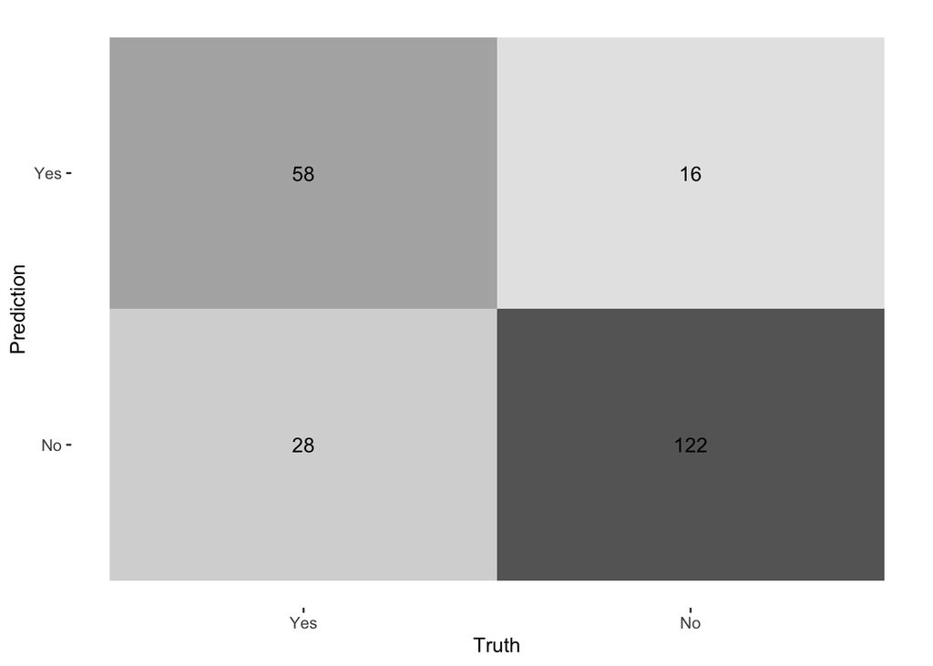

```r
log_test <- fit(log_wkflow, titanic_test)
log_results <- augment(log_test, new_data = titanic_test)

log_results %>%
  conf_mat(truth = survived, estimate = .pred_class) %>%
  autoplot(type = 'heatmap')
```

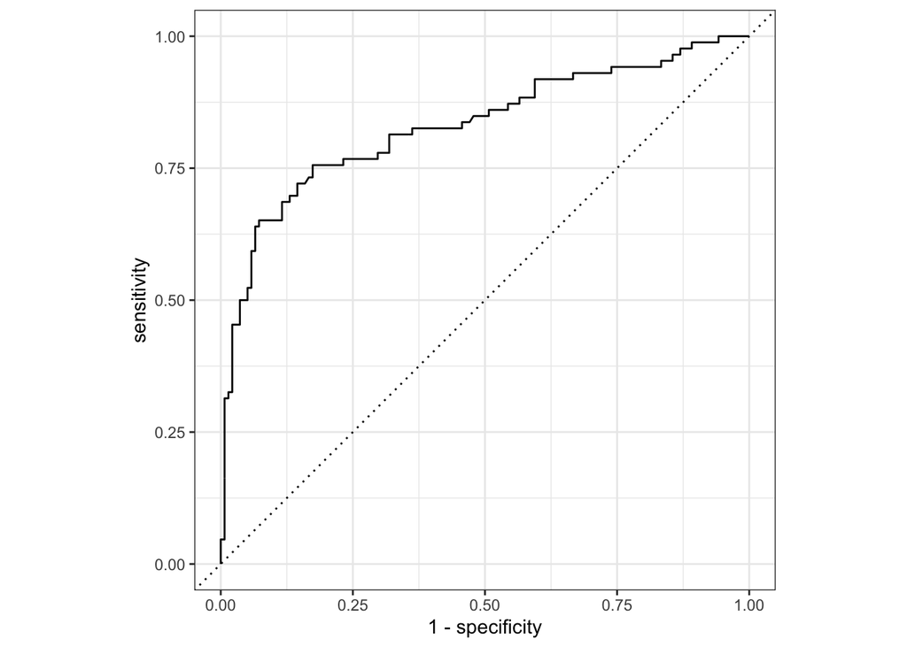

```r
log_results %>%
  roc_curve(survived, .pred_Yes) %>%
  autoplot()
```

```r
log_results %>%
  roc_auc(survived, .pred_Yes)
```

```
## # A tibble: 1 × 3
##   .metric .estimator .estimate
##   <chr>   <chr>          <dbl>
## 1 roc_auc binary         0.830
```

How did the model perform? Compare its training and testing accuracies. If the values differ, why do you think this is so?

```r
cat('Training Accuracy:', results$.estimate[1],
    '\nTesting Accuracy:', test_results$.estimate[1])
```

```
## Training Accuracy: 0.8170915
## Testing Accuracy: 0.7767857
```

### Required for 231 Students

In a binary classification problem, let $p$ represent the probability of class label $1$, which implies that $1 - p$ represents the probability of class label $0$. The *logistic function* (also called the “inverse logit”) is the cumulative distribution function of the logistic distribution, which maps a real number *z* to the open interval $(0, 1)$.

### Question 11

Given that:

$$p(z)=\frac{e^z}{1+e^z}$$

Prove that the inverse of a logistic function is indeed the *logit* function:

$$z(p)=ln\left(\frac{p}{1-p}\right)$$

### Question 12

Assume that $z = \beta_0 + \beta_{1}x_{1}$ and $p = logistic(z)$. How do the odds of the outcome change if you increase $x_{1}$ by two? Demonstrate this.

Assume now that $\beta_1$ is negative. What value does $p$ approach as $x_{1}$ approaches $\infty$? What value does $p$ approach as $x_{1}$ approaches $-\infty$?